# **Projeto Final - ICD**

## Impacto da Produção Agrícola no Desmatamento das Áreas de Floresta do Brasil

- Ana Luisa Mendes
- Higor Andrade
- Lorena Leão
- Maria Clara Ferreira
- Thiago Araújo

Link do vídeo do projeto: https://www.youtube.com/watch?v=8Bmo25-9GXI

## Dados Utilizados

- Brazilan Agricultural Production -

  https://www.kaggle.com/llatyki/brazilan-agricultural-production?select=yield.csv
- Brazilian Amazon Rainforest Degradation 1999-2019 -

  https://www.kaggle.com/mbogernetto/brazilian-amazon-rainforest-degradation?select=inpe_brazilian_amazon_fires_1999_2019.csv

## **1. Introdução**

O projeto tem como objetivo colocar em prática os conceitos aprendidos em aula.

### **Motivação:**

A escolha do tema partiu do interesse do grupo em analisar e entender como a ideologia do governo, em específico a orientação política do presidente, impacta as questões ambientais do Brasil. Para isso definimos as seguintes perguntas:

**1.** Como a ideologia do governo afeta a podução agrícola?

**2.** Existe uma correlação entreo desmatamento na Amazônia Legal e a orientação política do presidente?

**3.** Existe uma correlação entre a área plantada e o número de queimadas/área desmatada?

**4.** A orientação política do presidente tem algum impacto na quantidade de incêndios na Amazônia Legal?

**Observação:** o notebook com os códigos pode ser visto em: https://github.com/thiagomrs/icd2021projetoFinal/blob/main/Relatorio.ipynb

## **2. Análise Exploratória**

### **Dataset 1 - Brazilian Amazon Rainforest Degradation 1999-2019**

##### **Revised Data Dictionary**

| Variable | Description | Data Type |
| --- | --- | --- |
| year | Year of occurrence | Ordinal |
| month | Month of occurrence | Ordinal |
| state | State of occurrence | Nominal |
| latitude | Average latitude of all occurrences in this month, year and state | Numerical |
| longitude | Average longitude of all occurrences in this month, year and state | Numerical |
| firespots | Number of forest fire outbreaks | Numerical |

**Amazônia Legal**

Segundo o IBGE, "A Amazônia Legal corresponde à área de atuação da Superintendência de Desenvolvimento da Amazônia - SUDAM delimitada em consonância ao Art. 2o da Lei Complementar n. 124, de 03.01.2007. A região é composta por 772 municípios distribuídos da seguinte forma: 52 municípios de Rondônia, 22 municípios do Acre, 62 do Amazonas, 15 de Roraima, 144 do Pará, 16 do Amapá, 139 do Tocantins, 141 do Mato Grosso, bem como, por 181 Municípios do Estado do Maranhão situados ao oeste do Meridiano 44º, dos quais, 21 deles, estão parcialmente integrados na Amazônia Legal. Possui uma superfície aproximada de 5.015.067,75 km², correspondente a cerca de 58,9% do território brasileiro."

Fonte: https://www.ibge.gov.br/geociencias/cartas-e-mapas/mapas-regionais/15819-amazonia-legal.html?=&t=o-que-e

##### **Revised Data Dictionary**

| Variable | Description | Data Type |
| --- | --- | --- |
| Ano | Year of occurrence | Ordinal |
| AC | Deforested area in Acre state (km²) | Numerical |
| AM | Deforested area in Amazonas state (km²) | Numerical |
| AP | Deforested area in Amapa state (km²) | Numerical |
| MA | Deforested area in Maranhao state (km²) | Numerical |
| MT | Deforested area in Mato Grosso state (km²) | Numerical |
| PA | Deforested area in Para state (km²) | Numerical |
| RO | Deforested area in Rondonia state (km²) | Numerical |
| RR | Deforested area in Roraima state (km²) | Numerical |
| TO | Deforested area in Tocantins state (km²) | Numerical |
| AMZ LEGAL | Deforested area in Legal Amazon (km²) | Numerical |

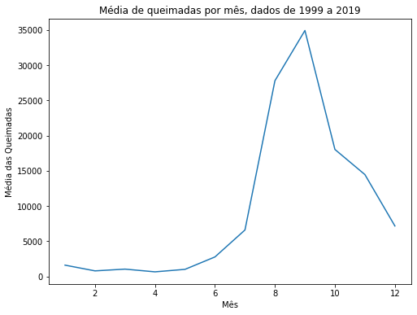

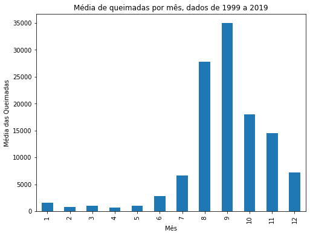

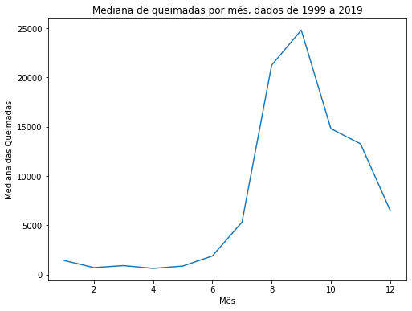

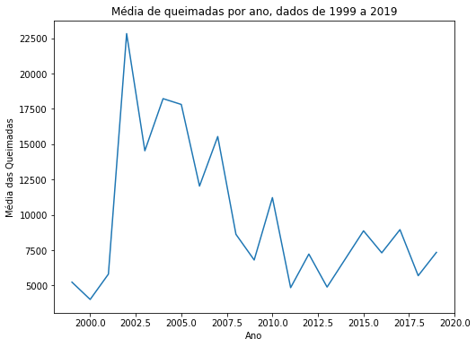

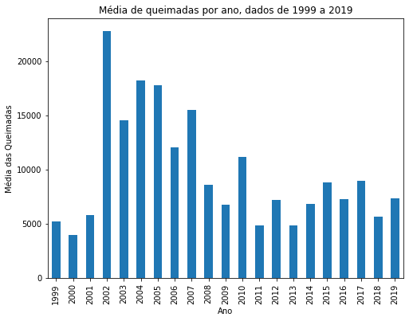

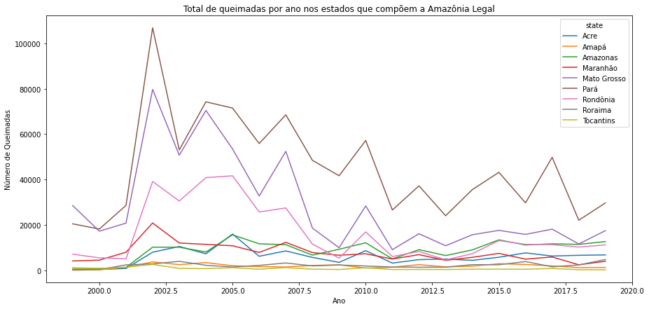

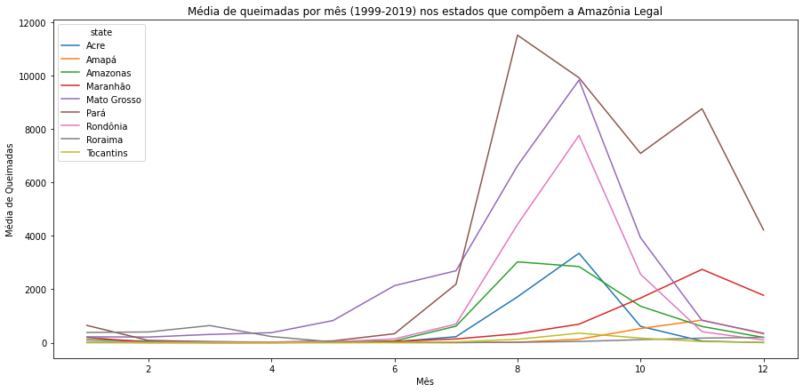

#### Média anual de queimadas por estado de 1999 a 2019

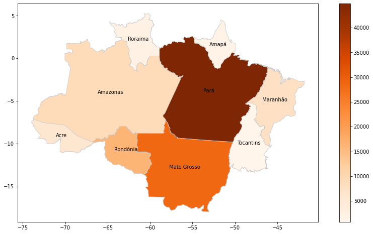

#### Distribuição de queimadas por mês

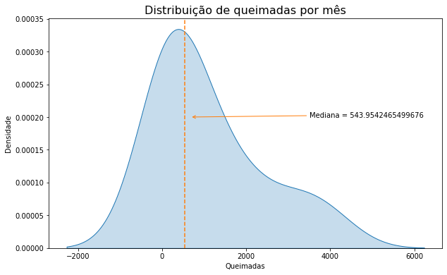

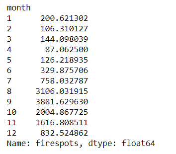

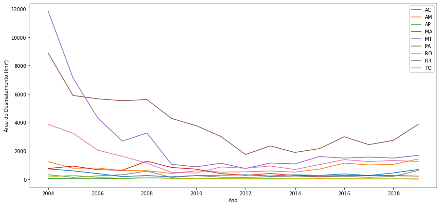

#### Média da área de desmatamento de 2004-2019

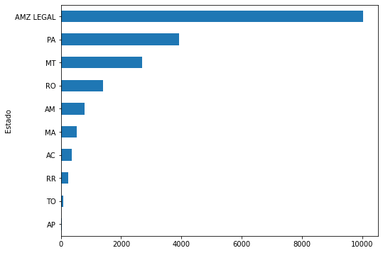

#### Agrupamento por presidentes (2004-2019)

**Lula (2004-2010)** De fato, de 2003 até 2010, mas a base começa em 2004.

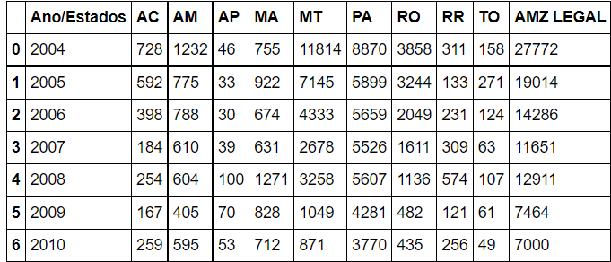

**Dilma (2011-2016)** De fato, até ago/2016, momento do impeachement.

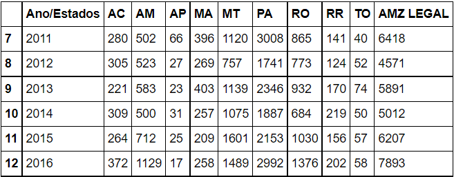

**Temer (2016-2018)**

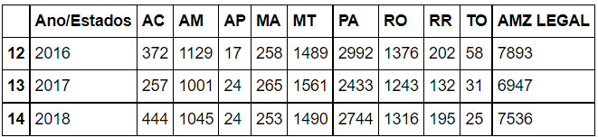

**Bolsonaro (2019-2019)** De fato, até 2021, contudo a base só vai até 2019

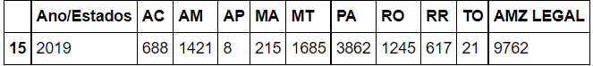

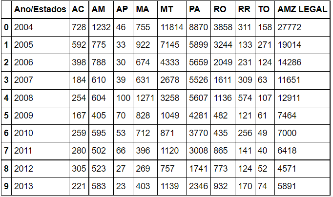

**Direita (2016-2019)**

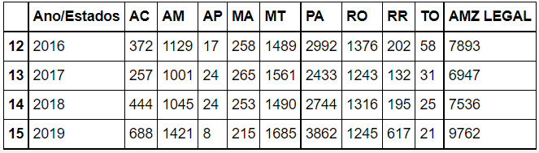

### **Dataset 2 - Brazilan Agricultural Production**

O dataset sobre a produção de grãos e área plantada possui dados de 1974 até 2019.

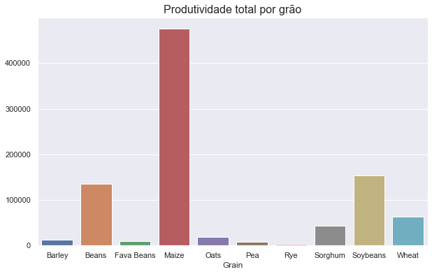

### Produtividade por grão por ano

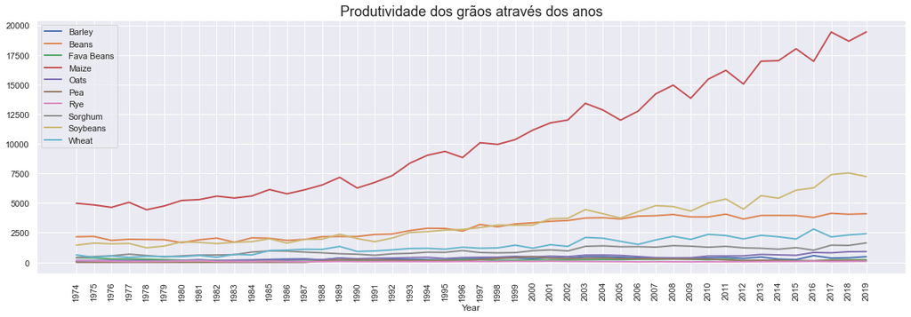

### Produtividade total por ano

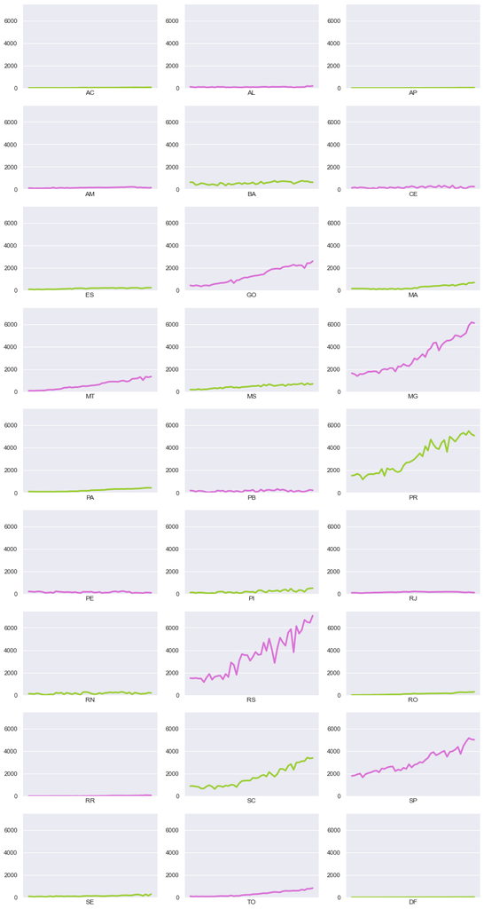

### Divisão por presidentes (Dados de 1974 - 2019)

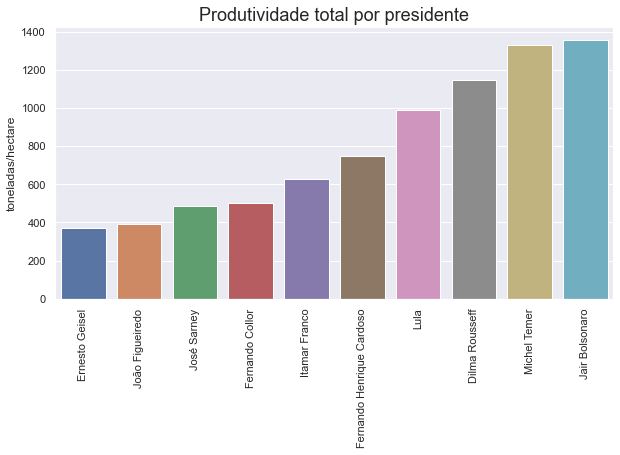

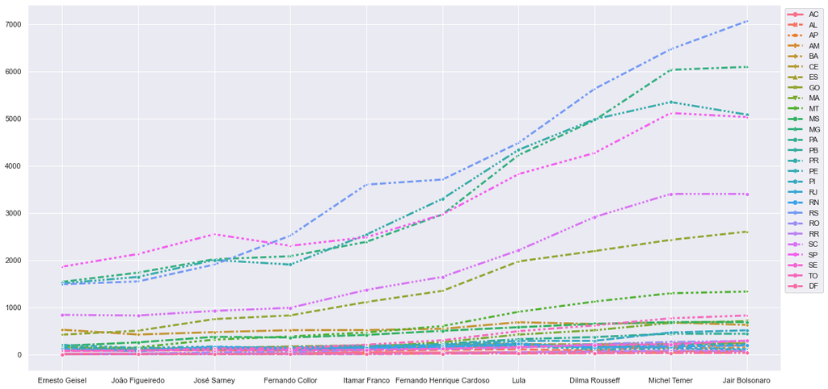

## **3. Teste de Hipotese**

### **Dataset 1 - Brazilian Amazon Rainforest Degradation 1999-2019**

#### **Teste 1:**

**Hipótese nula:** a orientação política do presidente não afeta o desmatamento na Amazônia legal

**Hipótese alternativa:** a orientação política do presidente afeta o desmatamento na Amazônia legal

AMZ LEGAL: Tabela t: alpha = 0.05, upper-tail, df = 15 (graus de liberdade) ---> (1.7531)

Se o valor t encontrado (0.42445502467144486) fosse maior que o valor da tabela, rejeitaria a hi nula. Como não é o caso, a hi nula não pode ser rejeitada.

**Observação:** a inclusão dos dados de 2020 possivelmente alteraria o resultado, devido a "passagem da boiada"

#### **Teste 2:**

**Hipótese nula:** a orientação política do presidente não afeta o número de focos de incêndio na amazônia legal

**Hipótese alternativa:** a orientação política do presidente afeta o número de focos de incêndio na amazônia legal

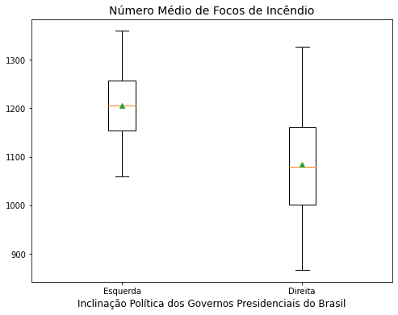

**Conclusão:** O Boxplot mostra que a orientação política do presidente não afeta, significativamente, o número de focos de incêncio na Amazônia.

### **Dataset 2 - Brazilan Agricultural Production**

**Hipótese nula:** a orientação política do presidente não afeta a produtividade agrícola de grãos durante seu mandato.  
**Hipótese alternativa:** a orientação política do presidente afeta a produtividade agrícola de grãos durante seu mandato.

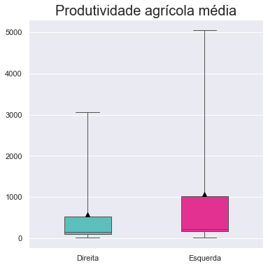

Não existe uma diferença significativa entre a produtividade de grãos com base na ideologia do presidente.

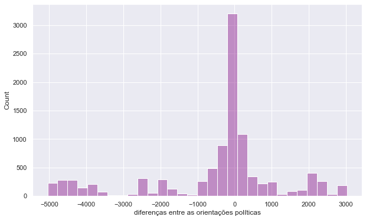

O histograma das diferenças entre a produtividade agrícola durante os mandatos de presidentes com orientações políticas diferentes tem uma alta concentração no zero, o que mostra que essas diferenças não são estatisticamente significativas

## **4. Correlação**

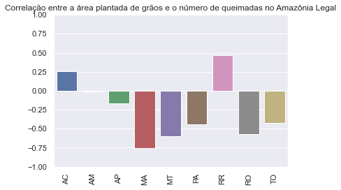

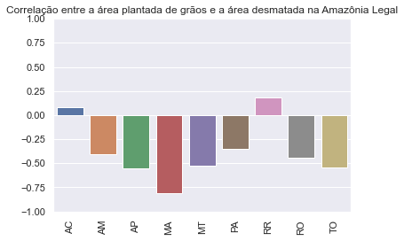

#### **Teste de Hipótese:**

**Hipótese nula:** as diferenças entre a correlação da área plantada e do número de queimadas/área desmatada podem ser devido ao acaso.

**Hipótese a ser testada:** essas diferenças podem ser atribuídas à ideologia do governo.

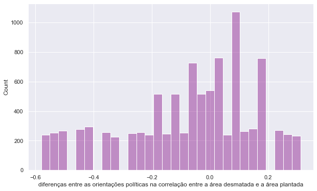

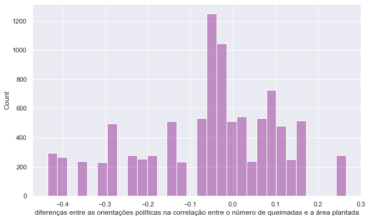

Não podemos rejeitar a hipótese nula em nenhuma dessas situações. Nada indica que a ideologia política do partido do presidente afeta a correlação entre a área plantada de grãos e o número de queimadas/área desmatada durante seu mandato.